# Boston Final Assignment-2

```python
import os
os.chdir("D:/Machine_Learning")
```

Importing Libraries

```python
import pandas as pd
import numpy as np
import matplotlib.pyplot as plt
import seaborn as sns
```

Loading 'Boston dataset'

```python
boston = pd.read_csv("D:/Machine_Learning/boston.csv")
```

```python
boston.info()
```

```
<class 'pandas.core.frame.DataFrame'>
RangeIndex: 506 entries, 0 to 505
Data columns (total 10 columns):
CRIM     506 non-null float64
INDUS    506 non-null float64
NOX      506 non-null float64
RM       506 non-null float64
AGE      506 non-null float64
DIS      506 non-null float64
TAX      506 non-null int64
PT       506 non-null float64
B        506 non-null float64
MV       506 non-null float64
dtypes: float64(9), int64(1)
memory usage: 39.6 KB
```

```python
boston['TAX'] = boston['TAX'].astype(float)
```

```python
boston.head()
```

|  | CRIM | INDUS | NOX | RM | AGE | DIS | TAX | PT | B | MV |
| --- | --- | --- | --- | --- | --- | --- | --- | --- | --- | --- |
| 0 | 0.00632 | 2.31 | 0.538 | 6.575 | 65.199997 | 4.0900 | 296.0 | 15.300000 | 396.899994 | 24.000000 |
| 1 | 0.02731 | 7.07 | 0.469 | 6.421 | 78.900002 | 4.9671 | 242.0 | 17.799999 | 396.899994 | 21.600000 |
| 2 | 0.02729 | 7.07 | 0.469 | 7.185 | 61.099998 | 4.9671 | 242.0 | 17.799999 | 392.829987 | 34.700001 |
| 3 | 0.03237 | 2.18 | 0.458 | 6.998 | 45.799999 | 6.0622 | 222.0 | 18.700001 | 394.630005 | 33.400002 |
| 4 | 0.06905 | 2.18 | 0.458 | 7.147 | 54.200001 | 6.0622 | 222.0 | 18.700001 | 396.899994 | 36.200001 |

```python
boston.shape
```

```
(506, 10)
```

# Summary Statistics

```python
boston.describe()
```

|  | CRIM | INDUS | NOX | RM | AGE | DIS | TAX | PT | B | MV |
| --- | --- | --- | --- | --- | --- | --- | --- | --- | --- | --- |
| count | 506.000000 | 506.000000 | 506.000000 | 506.000000 | 506.000000 | 506.000000 | 506.000000 | 506.000000 | 506.000000 | 506.000000 |
| mean | 3.613524 | 11.136779 | 0.554695 | 6.284634 | 68.574901 | 3.795043 | 408.237154 | 18.455534 | 356.674030 | 22.532806 |
| std | 8.601545 | 6.860353 | 0.115878 | 0.702617 | 28.148862 | 2.105710 | 168.537116 | 2.164946 | 91.294863 | 9.197104 |
| min | 0.006320 | 0.460000 | 0.385000 | 3.561000 | 2.900000 | 1.129600 | 187.000000 | 12.600000 | 0.320000 | 5.000000 |
| 25% | 0.082045 | 5.190000 | 0.449000 | 5.885500 | 45.025000 | 2.100175 | 279.000000 | 17.400000 | 375.377487 | 17.025000 |
| 50% | 0.256510 | 9.690000 | 0.538000 | 6.208500 | 77.500000 | 3.207450 | 330.000000 | 19.050000 | 391.440002 | 21.200001 |
| 75% | 3.677083 | 18.100000 | 0.624000 | 6.623500 | 94.074999 | 5.188425 | 666.000000 | 20.200001 | 396.225006 | 25.000000 |
| max | 88.976196 | 27.740000 | 0.871000 | 8.780000 | 100.000000 | 12.126500 | 711.000000 | 22.000000 | 396.899994 | 50.000000 |

Analysis: we have data from 506 neighborhoods in the Boston area.The below shown is the Central tendencies and distribution of some key features

[output not shown]

# Checking Linearity of the data - Scatterplots

Using scatterplots , take a look into the relationship between our Feautures and Target variabe

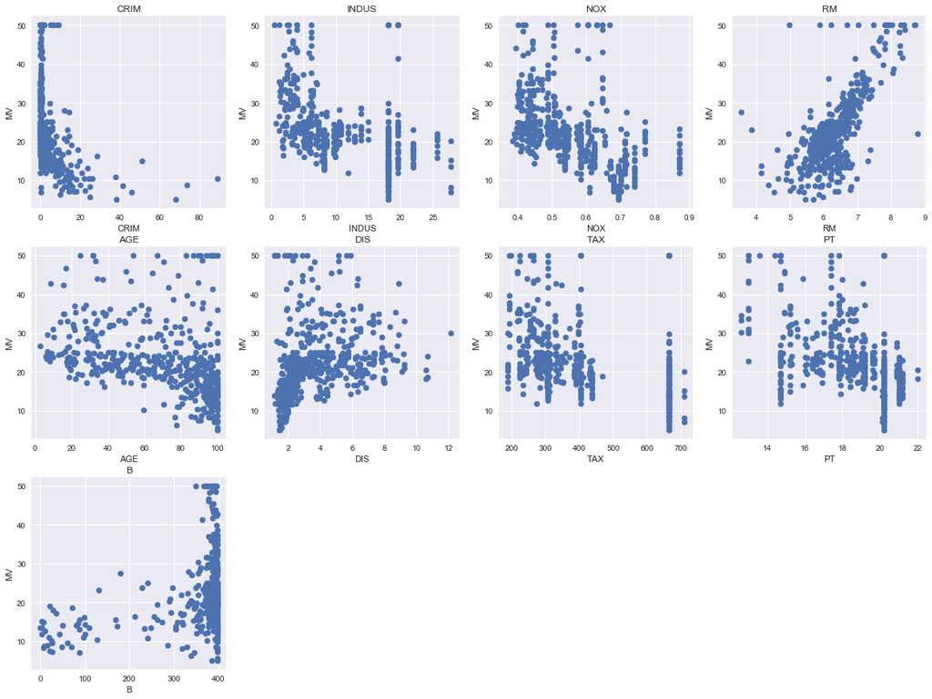

```python
plt.figure(figsize=(20, 15))
features = ['CRIM','INDUS','NOX','RM','AGE','DIS','TAX','PT','B']
target = boston['MV']
for i, col in enumerate(features):
    plt.subplot(3, len(features)/2 , i+1)
    x = boston[col]
    y = target
    plt.scatter(x, y, marker='o')
    plt.title(col)
    plt.xlabel(col)
    plt.ylabel('MV')
```

# Correlation between Features and Target Variables

Number of Rooms[MV]

```
Strong positive correlation between RM & MV so as the Number of Rooms increases/decreases the Median value of owner occupied house also increases/decreases
```

```
Text(0.5,1,'Relationship between RM and MV')
```

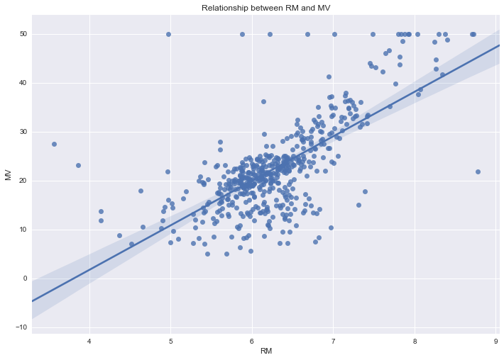

```python
sns.regplot(y="MV", x="RM", data=boston, fit_reg = True)
plt.title("Relationship between RM and MV")
```

Nitric Oxide Concentration[NoX]

```
Text(0.5,1,'Relationship between NOX and MV')
```

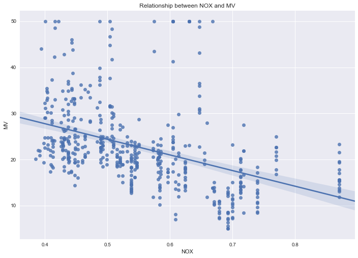

```python
sns.regplot(y="MV", x="NOX", data=boston, fit_reg = True)
plt.title("Relationship between NOX and MV")
```

Distance from 5 Major Employment Centers

```
Text(0.5,1,'Relationship between DIS and MV')
```

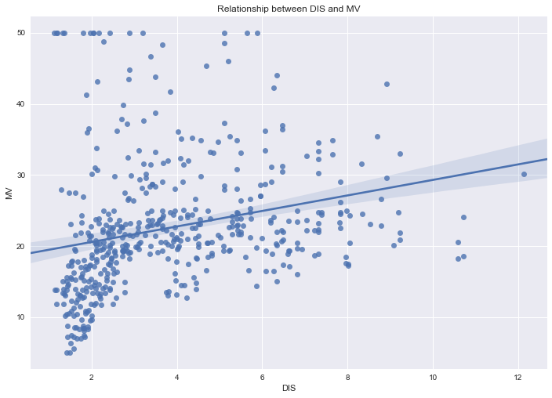

```python
sns.regplot(y="MV", x="DIS", data=boston, fit_reg = True)
plt.title("Relationship between DIS and MV")
```

Crime Rate

```
Text(0.5,1,'Relationship between CRIM and MV')
```

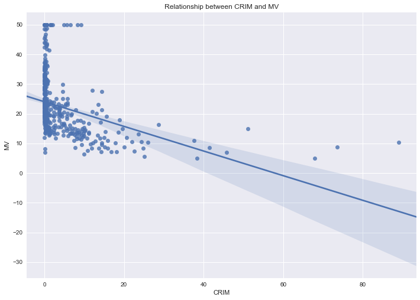

```python
sns.regplot(y="MV", x="CRIM", data=boston, fit_reg = True)
plt.title("Relationship between CRIM and MV")
```

AGE

```
Text(0.5,1,'Relationship between AGE and MV')
```

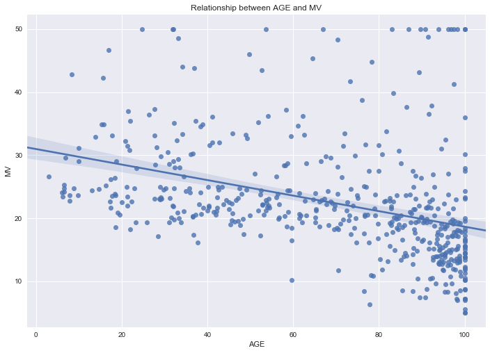

```python
sns.regplot(y="MV", x="AGE", data=boston, fit_reg = True)
plt.title("Relationship between AGE and MV")
```

INDUS

Strong Negative correlation between INDUS and MV

```
Text(0.5,1,'Relationship between INDUS and MV')
```

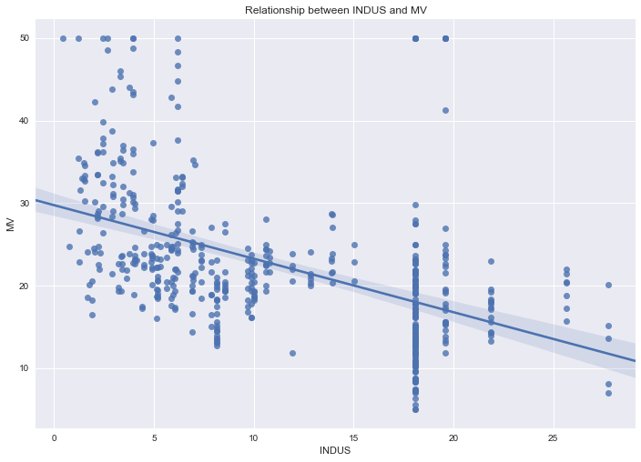

```python
sns.regplot(y="MV", x="INDUS", data=boston, fit_reg = True)
plt.title("Relationship between INDUS and MV")
```

TAX

Strong Negative correlation between TAX and MV

```
Text(0.5,1,'Relationship between TAX and MV')
```

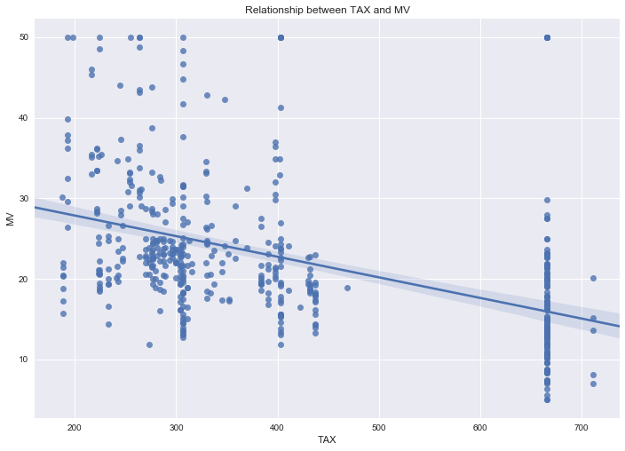

```python
sns.regplot(y="MV", x="TAX", data=boston, fit_reg = True)
plt.title("Relationship between TAX and MV")
```

Peoples Teacher Ratio[PT]

Strong Negative Correlation between PT and MV so No.of Students increases for every teacher the value of housing decreases

```
Text(0.5,1,'Relationship between PT and MV')
```

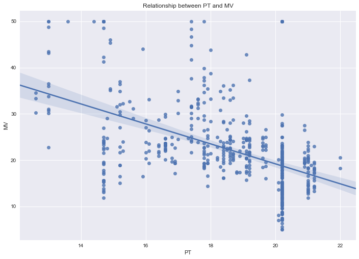

```python
sns.regplot(y="MV", x="PT", data=boston, fit_reg = True)
plt.title("Relationship between PT and MV")
```

Blacks

```
Text(0.5,1,'Relationship between B and MV')
```

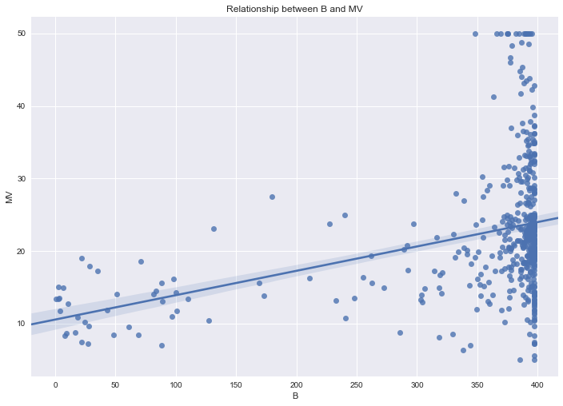

```python
sns.regplot(y="MV", x="B", data=boston, fit_reg = True)
plt.title("Relationship between B and MV")
```

# Normality Checking : Histograms

Checking the Variables is that the values are Normally distributed.

```
array([[<matplotlib.axes._subplots.AxesSubplot object at 0x000001C4335DA128>,
      dtype=object)
```

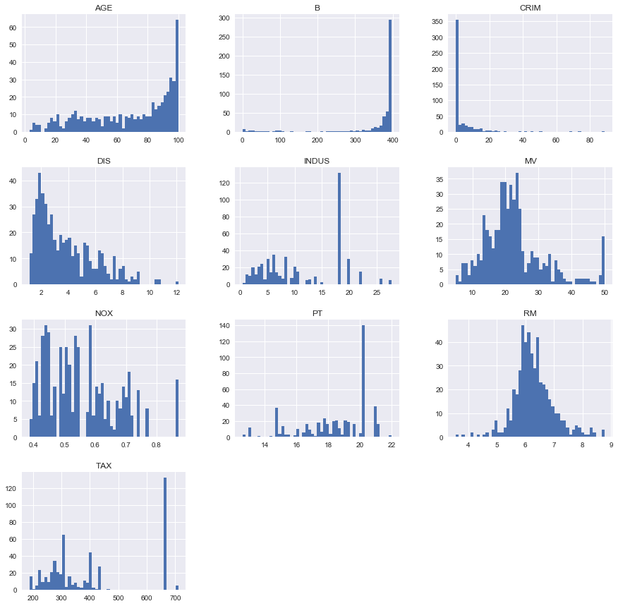

```python
boston.hist(bins=50, figsize=(15, 15))
```

# Distribution of the Target Variable [MV]

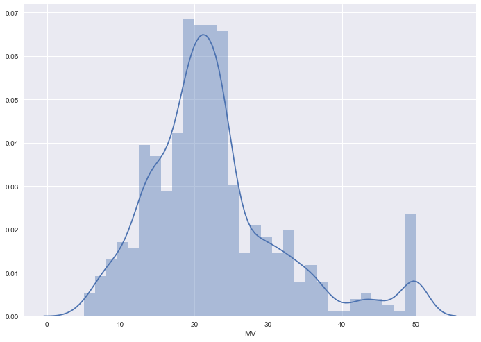

```python
sns.set(rc={'figure.figsize':(11.7,8.27)})
sns.distplot(boston['MV'], bins=30)
plt.show()
```

# Checking for correlation using Correlation Matrix

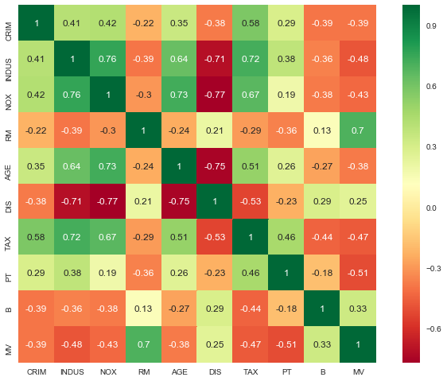

```python
sns.set(rc = {'figure.figsize':(11.8,8.27)})
sns.heatmap(boston.corr().round(2), square=True, cmap = 'RdYlGn',annot=True)
```

# Fitting Linear Regression using Statsmodels

```python
import statsmodels.api as sm
```

```python
from sklearn.model_selection import train_test_split
```

```python
X_train, X_test, Y_train, Y_test = train_test_split(boston.drop("MV",axis=1),boston['MV'],test_size=0.2,random_state=112)
```

```python
X_train = sm.add_constant(X_train)
```

```python
my_model = sm.OLS(Y_train, X_train)
```

```python
result = my_model.fit()
```

```python
print(result.summary())
```

```
                            OLS Regression Results
==============================================================================
Dep. Variable:                     MV   R-squared:                       0.642
Model:                            OLS   Adj. R-squared:                  0.633
Method:                 Least Squares   F-statistic:                     78.34
Date:                Tue, 10 Dec 2019   Prob (F-statistic):           3.48e-82
Time:                        10:47:04   Log-Likelihood:                -1257.7
No. Observations:                 404   AIC:                             2535.
Df Residuals:                     394   BIC:                             2575.
Df Model:                           9
Covariance Type:            nonrobust
==============================================================================
                 coef    std err          t      P>|t|      [0.025      0.975]
------------------------------------------------------------------------------
const         15.0719      6.031      2.499      0.013       3.215      26.929
CRIM          -0.1376      0.037     -3.706      0.000      -0.211      -0.065
INDUS         -0.1487      0.078     -1.916      0.056      -0.301       0.004
NOX          -15.1124      4.953     -3.051      0.002     -24.850      -5.375
RM             6.4231      0.450     14.282      0.000       5.539       7.307
AGE           -0.0569      0.016     -3.573      0.000      -0.088      -0.026
DIS           -1.3770      0.230     -5.981      0.000      -1.830      -0.924
TAX            0.0018      0.003      0.599      0.549      -0.004       0.008
PT            -0.9483      0.156     -6.082      0.000      -1.255      -0.642
B              0.0101      0.004      2.833      0.005       0.003       0.017
==============================================================================
Omnibus:                      254.801   Durbin-Watson:                   1.938
Prob(Omnibus):                  0.000   Jarque-Bera (JB):             3040.572
Skew:                           2.503   Prob(JB):                         0.00
Kurtosis:                      15.473   Cond. No.                     1.42e+04
==============================================================================

Warnings:
[1] Standard Errors assume that the covariance matrix of the errors is correctly specified.
[2] The condition number is large, 1.42e+04. This might indicate that there are
strong multicollinearity or other numerical problems.
```

Hence we can conclude that the increase/decrease in TAX can't play a significant role in the Median Value of owner occupied houses so we can remove Feature TAX from the features

also higher/lower in INDUS can't play a significant role in the Median Value of owner occupied houses so we can remove Feature INDUS from the features

Let's now test our inference and drop the TAX variable and use all the other Variables as Features of the data to predict the Median Value of the owner-occupied house[MV]

```python
X_train = X_train.drop("TAX",axis=1)
```

```python
updated_model_result = sm.OLS(Y_train, X_train).fit()
```

```python
print(updated_model_result.summary())
```

```
                            OLS Regression Results
==============================================================================
Dep. Variable:                     MV   R-squared:                       0.641
Model:                            OLS   Adj. R-squared:                  0.634
Method:                 Least Squares   F-statistic:                     88.23
Date:                Tue, 10 Dec 2019   Prob (F-statistic):           4.28e-83
Time:                        10:47:08   Log-Likelihood:                -1257.9
No. Observations:                 404   AIC:                             2534.
Df Residuals:                     395   BIC:                             2570.
Df Model:                           8
Covariance Type:            nonrobust
==============================================================================
                 coef    std err          t      P>|t|      [0.025      0.975]
------------------------------------------------------------------------------
const         14.4115      5.925      2.432      0.015       2.764      26.059
CRIM          -0.1297      0.035     -3.742      0.000      -0.198      -0.062
INDUS         -0.1301      0.071     -1.830      0.068      -0.270       0.010
NOX          -14.2188      4.720     -3.013      0.003     -23.497      -4.940
RM             6.4525      0.447     14.445      0.000       5.574       7.331
AGE           -0.0576      0.016     -3.629      0.000      -0.089      -0.026
DIS           -1.3603      0.228     -5.957      0.000      -1.809      -0.911
PT            -0.9186      0.148     -6.219      0.000      -1.209      -0.628
B              0.0098      0.004      2.782      0.006       0.003       0.017
==============================================================================
Omnibus:                      260.978   Durbin-Watson:                   1.940
Prob(Omnibus):                  0.000   Jarque-Bera (JB):             3237.494
Skew:                           2.572   Prob(JB):                         0.00
Kurtosis:                      15.879   Cond. No.                     9.25e+03
==============================================================================

Warnings:
[1] Standard Errors assume that the covariance matrix of the errors is correctly specified.
[2] The condition number is large, 9.25e+03. This might indicate that there are
strong multicollinearity or other numerical problems.
```

We see that even though our Rsquared value has very slightly decreased, but the Adjusted Rsquared value has increased. This confirms that the TAX variable wasn't significant in calculating the Median Value of owner occupied homes and by keeping the TAX variable, the adjusted R2 value was penalized.

Let's also see the accuracy ( R2 ) value on the test set, with this updated model.

```python
from sklearn.metrics import r2_score
```

```python
X_test = X_test.drop("TAX",axis=1)
```

```python
predictions2 = updated_model_result.predict(sm.add_constant(X_test))
```

```python
r2_score(Y_test, predictions2)
```

```
0.7259104836332607
```

```python
updated_model_result.rsquared
```

```
0.6411907503214512
```

```python
mean_absolute_error(Y_test, predictions2)
```

```
3.5086179037490055
```

Removing "INDUS" variable from the Features

```python
X_train = X_train.drop("INDUS",axis=1)
```

```python
updated_model_result2 = sm.OLS(Y_train, X_train).fit()
```

```python
print(updated_model_result2.summary())
```

```
                            OLS Regression Results
==============================================================================
Dep. Variable:                     MV   R-squared:                       0.638
Model:                            OLS   Adj. R-squared:                  0.632
Method:                 Least Squares   F-statistic:                     99.77
Date:                Tue, 10 Dec 2019   Prob (F-statistic):           2.16e-83
Time:                        10:47:27   Log-Likelihood:                -1259.6
No. Observations:                 404   AIC:                             2535.
Df Residuals:                     396   BIC:                             2567.
Df Model:                           7
Covariance Type:            nonrobust
==============================================================================
                 coef    std err          t      P>|t|      [0.025      0.975]
------------------------------------------------------------------------------
const         14.4501      5.942      2.432      0.015       2.768      26.132
CRIM          -0.1313      0.035     -3.779      0.000      -0.200      -0.063
NOX          -17.6109      4.353     -4.045      0.000     -26.169      -9.052
RM             6.6400      0.436     15.226      0.000       5.783       7.497
AGE           -0.0593      0.016     -3.731      0.000      -0.091      -0.028
DIS           -1.2635      0.223     -5.671      0.000      -1.701      -0.825
PT            -0.9857      0.144     -6.869      0.000      -1.268      -0.704
B              0.0105      0.004      2.963      0.003       0.004       0.017
==============================================================================
Omnibus:                      256.523   Durbin-Watson:                   1.966
Prob(Omnibus):                  0.000   Jarque-Bera (JB):             3100.357
Skew:                           2.521   Prob(JB):                         0.00
Kurtosis:                      15.600   Cond. No.                     9.14e+03
==============================================================================

Warnings:
[1] Standard Errors assume that the covariance matrix of the errors is correctly specified.
[2] The condition number is large, 9.14e+03. This might indicate that there are
strong multicollinearity or other numerical problems.
```

Interpreting Coefficient of the Predictors:

1) With the Increase of Crime rate by 1% we expect the Median value of owner occupied homes reduced by 131.3 USD

2) With the Increase of Nitric Oxide Concentration percentage by 1% we expect the Median value of owner occupied homes reduced by 1761 USD

3) With the Increase of Number of rooms by [lets say 1 room] we expect the Median value of owner occupied homes increases by 6640 USD

4) With the Increase of AGE by 1 year we expect the Median value of owner occupied homes reduced by 0593 USD

5) With the Increase of Weighted Distance to five boston employment centers by 1KM we expect the Median value of owner occupied homes reduced by 1263 USD

6) With the Increase of Peoples teacher ratio by 1% we expect the Median value of owner occupied homes reduced by 0985 USD

```python
print(updated_model_result2.summary2())
```

```
                 Results: Ordinary least squares
==================================================================
Model:              OLS              Adj. R-squared:     0.632
Dependent Variable: MV               AIC:                2535.1414
Date:               2019-12-10 10:47 BIC:                2567.1527
No. Observations:   404              Log-Likelihood:     -1259.6
Df Model:           7                F-statistic:        99.77
Df Residuals:       396              Prob (F-statistic): 2.16e-83
R-squared:          0.638            Scale:              30.497
--------------------------------------------------------------------
          Coef.     Std.Err.      t      P>|t|     [0.025     0.975]
--------------------------------------------------------------------
const     14.4501     5.9422    2.4318   0.0155     2.7678   26.1324
CRIM      -0.1313     0.0347   -3.7786   0.0002    -0.1996   -0.0630
NOX      -17.6109     4.3533   -4.0454   0.0001   -26.1694   -9.0524
RM         6.6400     0.4361   15.2260   0.0000     5.7826    7.4973
AGE       -0.0593     0.0159   -3.7311   0.0002    -0.0905   -0.0280
DIS       -1.2635     0.2228   -5.6713   0.0000    -1.7014   -0.8255
PT        -0.9857     0.1435   -6.8688   0.0000    -1.2679   -0.7036
B          0.0105     0.0035    2.9626   0.0032     0.0035    0.0174
------------------------------------------------------------------
Omnibus:              256.523      Durbin-Watson:         1.966
Prob(Omnibus):        0.000        Jarque-Bera (JB):      3100.357
Skew:                 2.521        Prob(JB):              0.000
Kurtosis:             15.600       Condition No.:         9144
==================================================================
* The condition number is large (9e+03). This might indicate
strong multicollinearity or other numerical problems.
```

Let's also see the accuracy ( R2 ) value on the test set, with this updated model.

```python
X_test = X_test.drop("INDUS",axis=1)
```

```python
predictions3 = updated_model_result2.predict(sm.add_constant(X_test))
```

R2_score

```python
r2_score(Y_test, predictions3)
```

```
0.7341993321923447
```

```python
updated_model_result2.rsquared
```

```
0.6381476842949687
```

```python
mean_absolute_error(Y_test, predictions3)
```

```
3.462822477847536
```

# Variance Inflation Factor

```python
def vif_summary(input_data, dependent_col):
    x_vars = input_data.drop([dependent_col],axis=1)
    xvar_names=x_vars.columns
    for i in range(0,xvar_names.shape[0]):
        y=x_vars[xvar_names[i]]
        x=x_vars[xvar_names.drop(xvar_names[i])]
        rsquare=sm.OLS(y,x).fit().rsquared
        vif=round(1/(1-rsquare),2)
        print(xvar_names[i],"VIF=",vif)
```

```python
vif_summary(input_data=boston, dependent_col="MV")
```

```
CRIM VIF= 1.89
INDUS VIF= 13.17
NOX VIF= 67.47
RM VIF= 55.39
AGE VIF= 18.71
DIS VIF= 10.74
TAX VIF= 21.4
PT VIF= 65.73
B VIF= 19.37
```

Even though some features showing high VIF because of the Multi-collineairty that is there is a high correlation between the Independent Feature Variables.

but Even after removing the High correlated Feature my RSquared value went down and also accuracy is poor on test dataset.

Below I tried to remove the high correlated variables but the model leads to low Rsquared value and its performance is poor because even having correlation between these variable so outside factors are influencing the predicted value so these variables are important for my model so im not removing these Highly-Correlated variables

# Q-Q plot

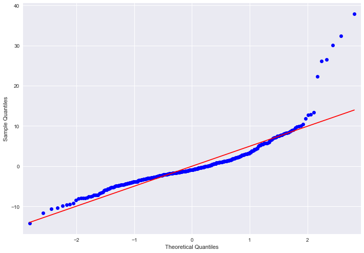

```python
qqfig = sm.qqplot(updated_model_result2.resid,line='r')
```

The Linear Regression line fits good but there are some outliers we need to invest them further

# Reason why im not removing high Correlated values

# Variance-Inflation Factor

```python
def vif_summary(input_data, dependent_col):
    x_vars = input_data.drop([dependent_col],axis=1)
    xvar_names=x_vars.columns
    for i in range(0,xvar_names.shape[0]):
        y=x_vars[xvar_names[i]]
        x=x_vars[xvar_names.drop(xvar_names[i])]
        rsquare=sm.OLS(y,x).fit().rsquared
        vif=round(1/(1-rsquare),2)
        print(xvar_names[i],"VIF=",vif)
```

```python
vif_summary(input_data=boston, dependent_col="MV")
```

```
CRIM VIF= 1.89
INDUS VIF= 13.17
NOX VIF= 67.47
RM VIF= 55.39
AGE VIF= 18.71
DIS VIF= 10.74
TAX VIF= 21.4
PT VIF= 65.73
B VIF= 19.37
```

```python
X_train = X_train.drop("DIS",axis=1)
```

```python
updated_model_result3 = sm.OLS(Y_train, X_train).fit()
```

```python
print(updated_model_result3.summary())
```

```
                            OLS Regression Results
==============================================================================
Dep. Variable:                     MV   R-squared:                       0.609
Model:                            OLS   Adj. R-squared:                  0.603
Method:                 Least Squares   F-statistic:                     103.0
Date:                Tue, 10 Dec 2019   Prob (F-statistic):           9.40e-78
Time:                        10:47:42   Log-Likelihood:                -1275.3
No. Observations:                 404   AIC:                             2565.
Df Residuals:                     397   BIC:                             2593.
Df Model:                           6
Covariance Type:            nonrobust
==============================================================================
                 coef    std err          t      P>|t|      [0.025      0.975]
------------------------------------------------------------------------------
const         -2.6461      5.318     -0.498      0.619     -13.101       7.809
CRIM          -0.1195      0.036     -3.318      0.001      -0.190      -0.049
NOX           -5.5336      3.943     -1.403      0.161     -13.285       2.218
RM             6.9141      0.450     15.361      0.000       6.029       7.799
AGE           -0.0239      0.015     -1.573      0.117      -0.054       0.006
PT            -0.9213      0.149     -6.201      0.000      -1.213      -0.629
B              0.0110      0.004      2.997      0.003       0.004       0.018
==============================================================================
Omnibus:                      256.370   Durbin-Watson:                   1.990
Prob(Omnibus):                  0.000   Jarque-Bera (JB):             3079.891
Skew:                           2.521   Prob(JB):                         0.00
Kurtosis:                      15.551   Cond. No.                     7.64e+03
==============================================================================

Warnings:
[1] Standard Errors assume that the covariance matrix of the errors is correctly specified.
[2] The condition number is large, 7.64e+03. This might indicate that there are
strong multicollinearity or other numerical problems.
```

```python
from sklearn.metrics import r2_score
```

```python
X_test = X_test.drop("DIS",axis=1)
```

```python
predictions4 = updated_model_result3.predict(sm.add_constant(X_test))
```

```python
r2_score(Y_test, predictions4)
```

```
0.7038825699799451
```

```python
updated_model_result3.rsquared
```

```
0.6087574549942628
```

```python
mean_absolute_error(Y_test, predictions4)
```

```
3.582346385798733
```

```python
X_train = X_train.drop("NOX",axis=1)
```

```python
updated_model_result4 = sm.OLS(Y_train, X_train).fit()
```

```python
print(updated_model_result4.summary())
```

```
                            OLS Regression Results
==============================================================================
Dep. Variable:                     MV   R-squared:                       0.607
Model:                            OLS   Adj. R-squared:                  0.602
Method:                 Least Squares   F-statistic:                     122.9
Date:                Tue, 10 Dec 2019   Prob (F-statistic):           2.14e-78
Time:                        10:48:03   Log-Likelihood:                -1276.3
No. Observations:                 404   AIC:                             2565.
Df Residuals:                     398   BIC:                             2589.
Df Model:                           5
Covariance Type:            nonrobust
==============================================================================
                 coef    std err          t      P>|t|      [0.025      0.975]
------------------------------------------------------------------------------
const         -6.1364      4.706     -1.304      0.193     -15.389       3.116
CRIM          -0.1288      0.035     -3.633      0.000      -0.198      -0.059
RM             7.0368      0.442     15.918      0.000       6.168       7.906
AGE           -0.0380      0.011     -3.337      0.001      -0.060      -0.016
PT            -0.9044      0.148     -6.100      0.000      -1.196      -0.613
B              0.0120      0.004      3.330      0.001       0.005       0.019
==============================================================================
Omnibus:                      253.175   Durbin-Watson:                   1.997
Prob(Omnibus):                  0.000   Jarque-Bera (JB):             3017.818
Skew:                           2.481   Prob(JB):                         0.00
Kurtosis:                      15.436   Cond. No.                     6.20e+03
==============================================================================

Warnings:
[1] Standard Errors assume that the covariance matrix of the errors is correctly specified.
[2] The condition number is large, 6.2e+03. This might indicate that there are
strong multicollinearity or other numerical problems.
```

```python
from sklearn.metrics import r2_score
```

```python
X_test = X_test.drop("NOX",axis=1)
```

```python
predictions5 = updated_model_result4.predict(sm.add_constant(X_test))
```

```python
r2_score(Y_test, predictions5)
```

```
0.6952800933502064
```

```python
updated_model_result4.rsquared
```

```
0.6068166098421786
```

```python
mean_absolute_error(Y_test, predictions5)
```

```
3.627211780448132
```